# XCO research notes

# 1 XCO research notes

## 1.1 Basic ideas and theory

XCO takes futures positions in one type of commodity versus a basket. Both legs are normalized to the same expected standard deviations. The expected market beta of the relative position is hedged using a global directional risk basket.

The universe of liquid commodities that can be traded for relative value encompasses five groups: (i) base metals (aluminium, copper, zinc, nickel, lead), (ii) precious metals (gold, silver), (iii) agricultural products (corn, wheat, soybean, coffee, sugar, cotton), (iv) livestock (lean hogs, live cattle), (v) energy (Brent, WTI, US natural gas). For now U.S. crude and natural gas have been suspended due to their pronounced idiosyncrasies and strong dependence on local infrastructure.

An important difference between XCO and the other cross styles is that the underlying assets are group-wise very heterogeneous. For example, base metals as a group carries very different characteristics compared to agricultural goods. It follows that this strategy, like no other, relies on factors with selective impact (i.e. that only influence certain cross sections) or ad-hoc section-specific coefficients for a global factor.

In general, the decision on long and short positions are based on four types of factors:

- **Valuation gap**: These factors should indicate gaps between a commodity futures price and its estimated fair value. It is practically impossible to estimate a sustainable clearing price. However, four concepts seem to have potential.
  - **Soft arbitrage relations**: Many commodities have substitutes that are physically or spatially separated from the underlying of a futures contract. Due to frictions, short-term divergence can occur and be sizeable. However, over the medium-term they should act as an *“elastic band”*, pulling substitutes’ price back closer together, through mechanisms like physical transport, supply adjustments, or storage adjustments.
  - **The divergent impact of macroeconomic changes**: Some commodities are more sensitive to the global business cycle than others. To the extent that the market does not immediately and correctly account for changing business cycle indicators (particularly in the manufacturing sector), profit opportunities arise.
  - **Hedge value change**: In times of exogenous commodity price shocks, being long commodities provides a hedge against related inflation and terms-of-trade pressure. Put simply, negative correlation gives commodity futures a hedge value. Hence, changes in correlation can lead to sluggish adjustment in positions and underperformance.
  - **Crop cycles**: Plausible patterns of supply responses to past price developments can improve forecast of subsequent medium-term price trends in the agricultural commodity price space.
- **Implicit subsidies**: In the case of commodities, these are effectively premiums being paid by industrial suppliers and consumers: Unlike purely financial assets, commodities involve physical suppliers and consumers. These participants act on considerations beyond standard portfolio optimization. For example, commodity producers have a preference for future price certainty and may offer a discount on futures prices. Analogously, commodity consumers may be more averse to supply risk and hence prefer to buy spot (or the physical) at a premium to futures prices. These effects often manifest in a bias of the futures curve, via-a-vis a simple financial equilibrium and, thereby, offer a profit opportunity for financial investors.
- **Setback risk**: Setback risk factors might apply to conventional CTA signals and conventional carry measures. This needs more work. A setback risk indicator could be positioning indicators, which are more widely available than for other asset classes and can serve as a direct indicator of setback risk.
- **Distortion payback**: This factor is generally defined as the expected correction to a non-fundamental temporary price change. Changes in risk factors (such as beta and volatility) can trigger institutional selling and buying, following rigid risk management rules or investment mandates. In addition, the hedge value of commodity positions may lead to dislocations.

Many huge relative price moves in commodities ultimately reflect changes in underlying physical conditions that are beyond the scope of macro trading. Typically, these relate to supply side shocks, such as weather, epidemics, political events, or fund closures. Therefore, tight concentration limits of exposure in a specific commodity or a commodity group are of the essence.

The reduced-form factor structure is as follows:  
1. Excess real yields  
2. Short-term inflation dynamics  
3. Private credit dynamics

## 1.2 Target return properties

Commodity contracts display significant differences in price volatility, supporting normalization of positions as a preparatory step. Normalized returns look reasonably homogeneous across sections. The tails of distribution have been fat (with excess kurtosis at 1.8). There has been no sign of first-order autocorrelation for the group on average. However, there has been 23% first-order autocorrelation in Brent and 20% is sugar.

Cumulative normalized commodity returns have been positive since 1999, with pronounced cycles and occasional drastic adjustments. Brent crude oil showed a proclivity to losing 5-year positive return gains in the space of a few months. As to base metals, despite their pronounced short-term correlation they displayed remarkably diverse long-term performance. Gold and silver appear to have been driven by a single mega-cycle, possibly accentuated by fears over quantitative easing in the post-crisis years. Corn-belt crops, like base metals, posted divergent long-term trends, with soy gaining and wheat losing quite consistently over the past 15 years. Livestock posted the most irregular patterns with no clear trend and massive occasional price adjustments. The latter would be very hard to “risk manage”.

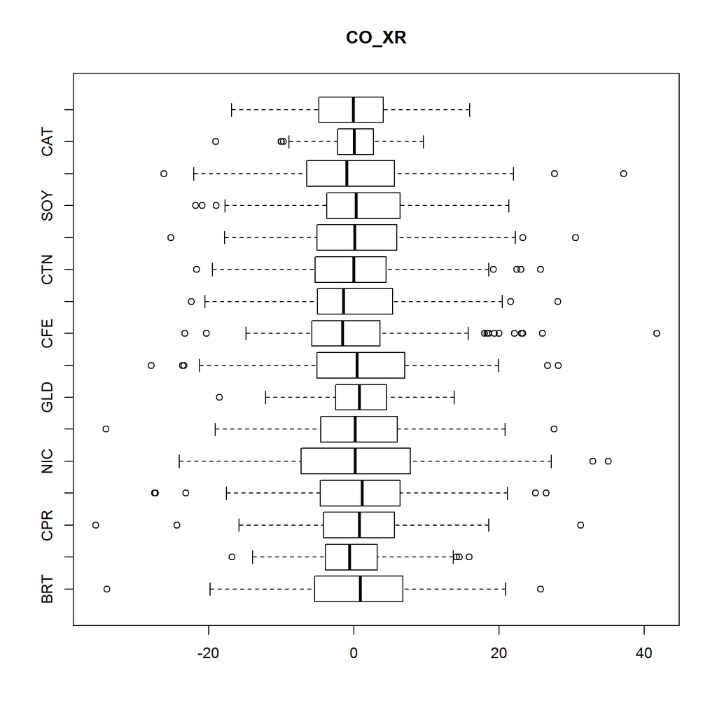

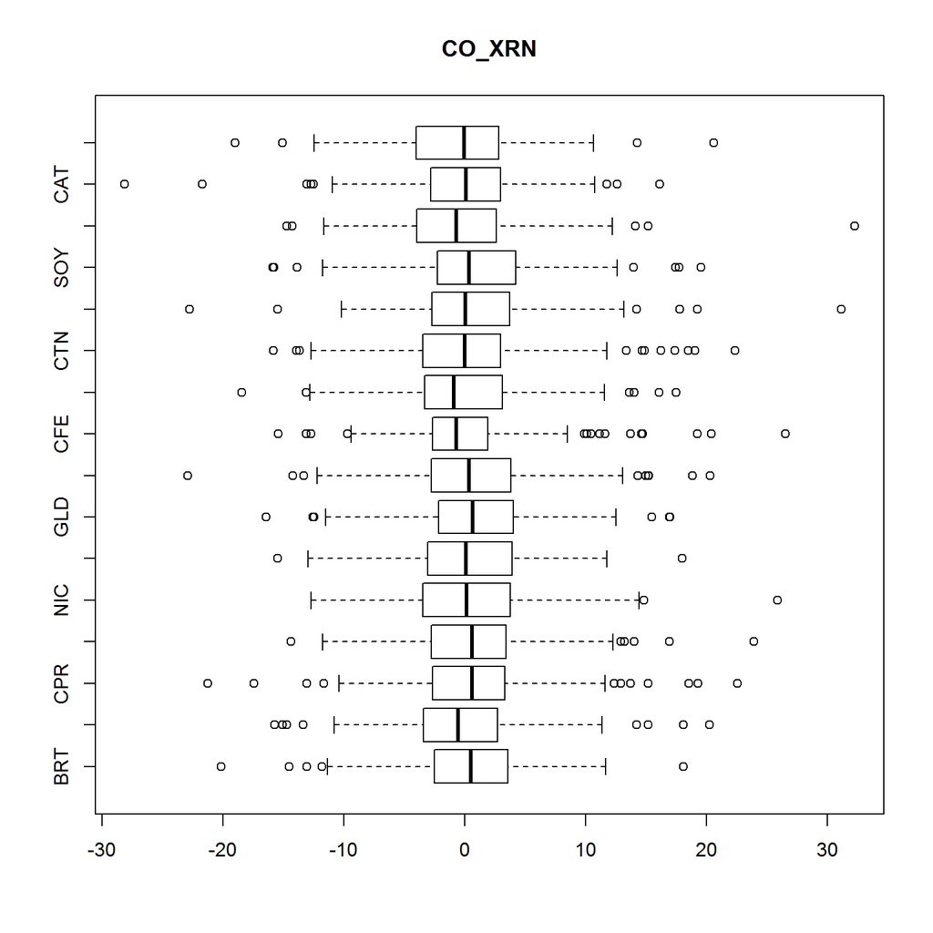

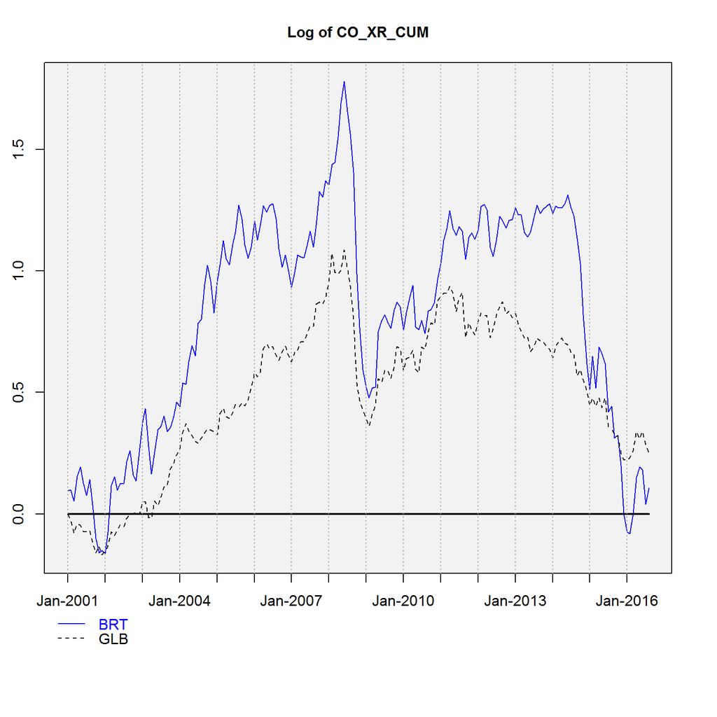

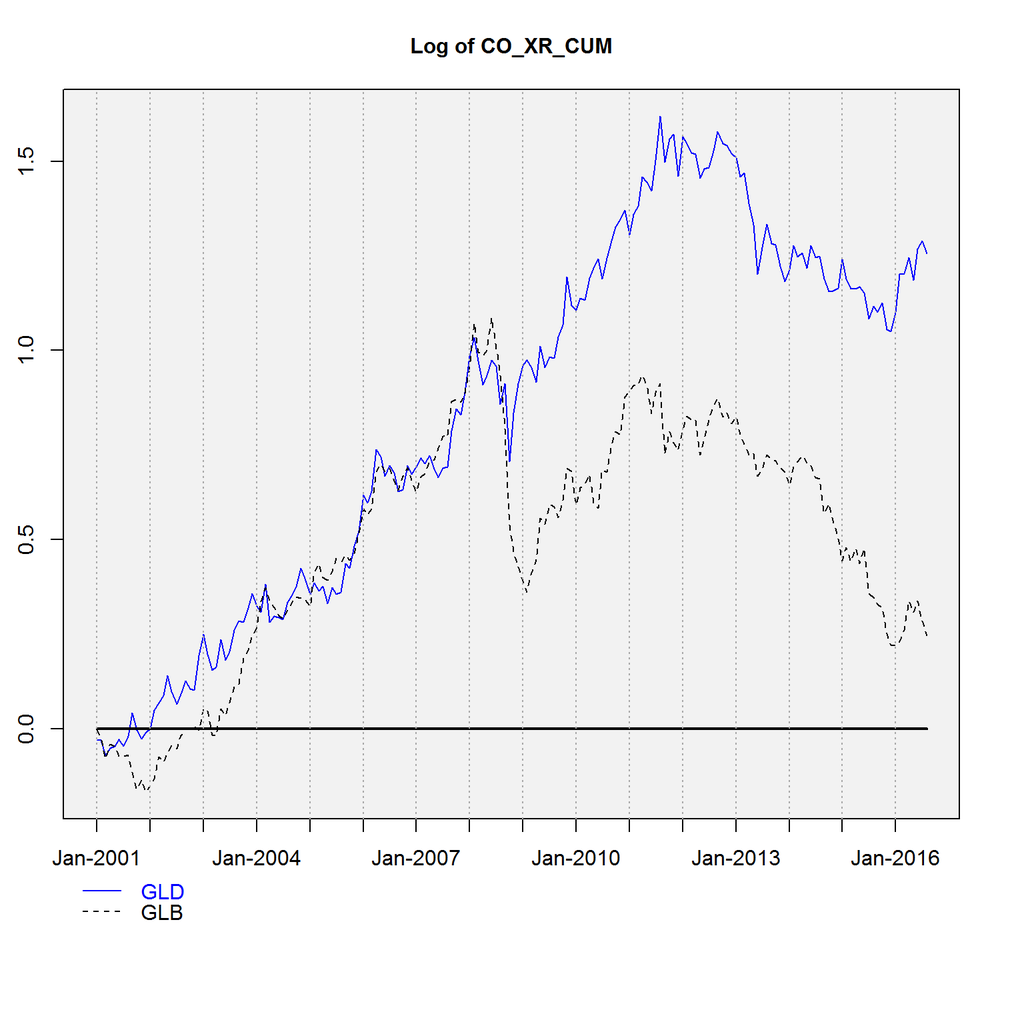

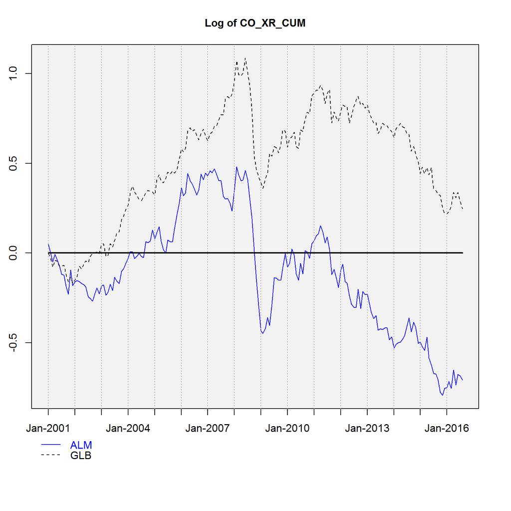

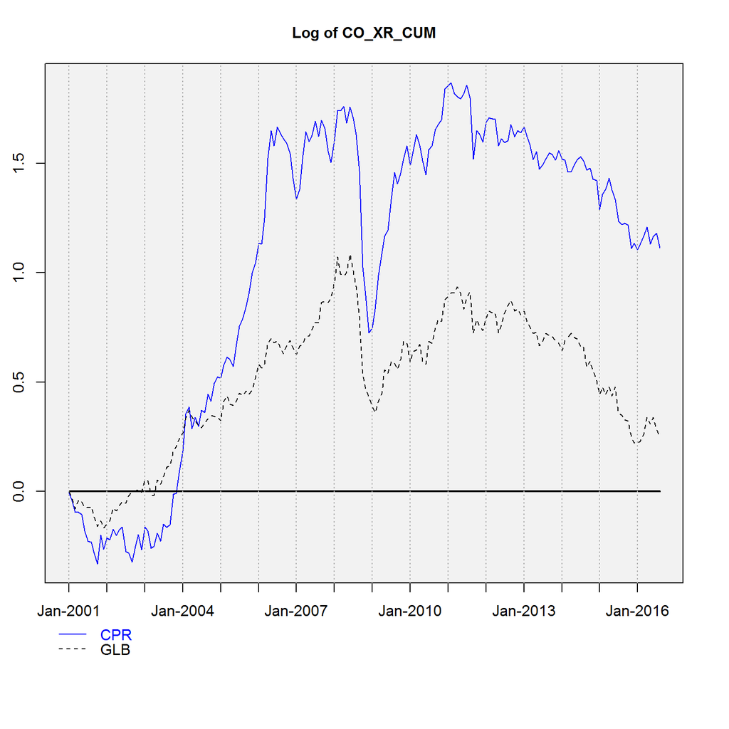

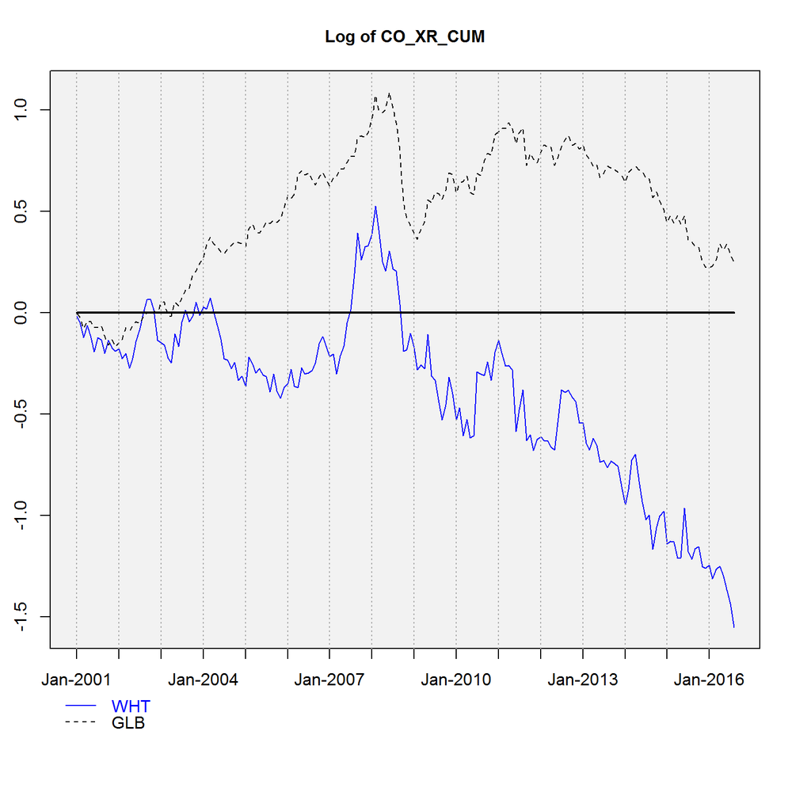

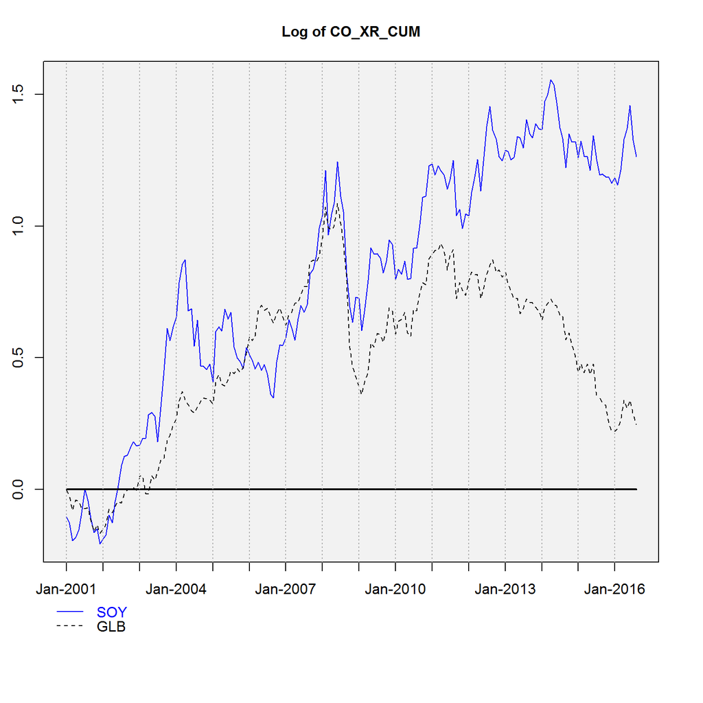

If commodity positions are hedged against global directional risk, they no longer post a positive return over the past 15 years. Put differently, positive returns on commodity futures are probably accounted for by a premium charged for directional market exposure. Indeed, agricultural commodities mostly posted long-term losses. Base metals were flat, with aluminium and nickel posting massive long-term declines.

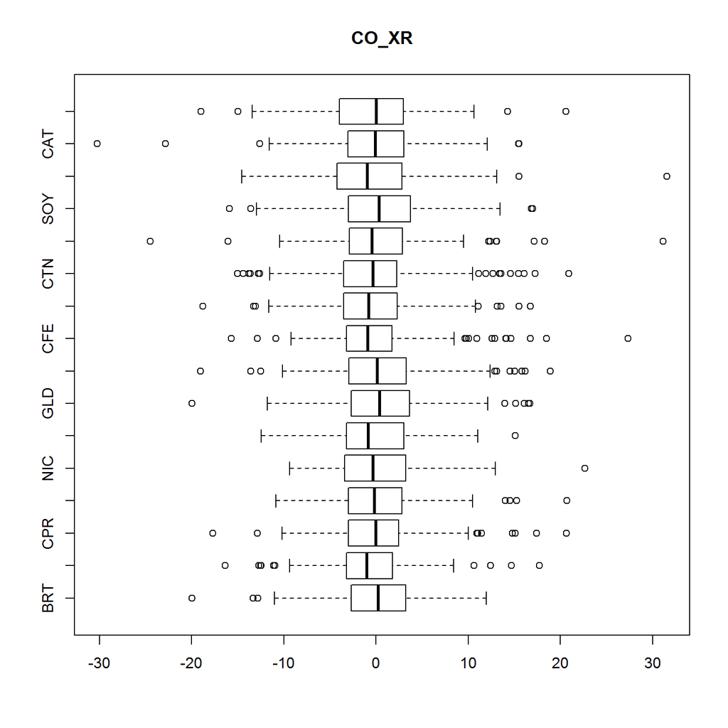

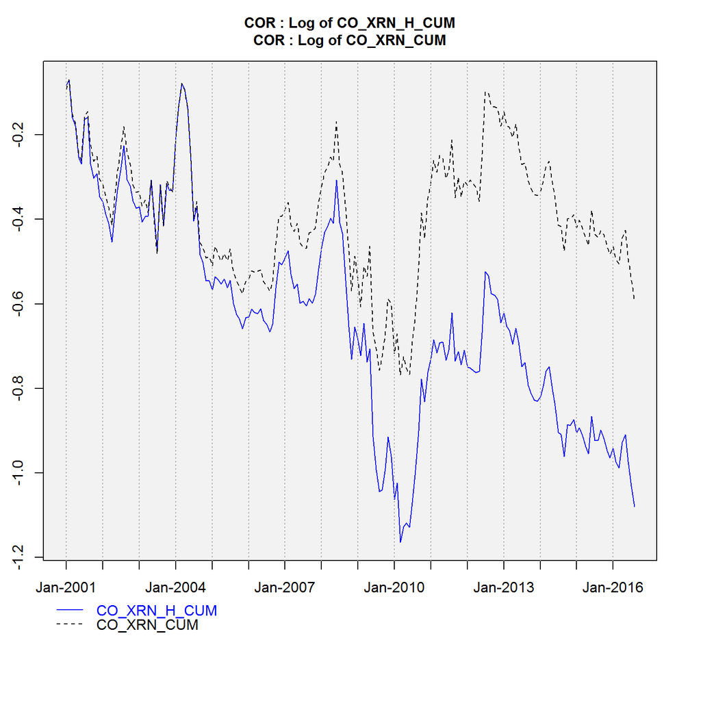

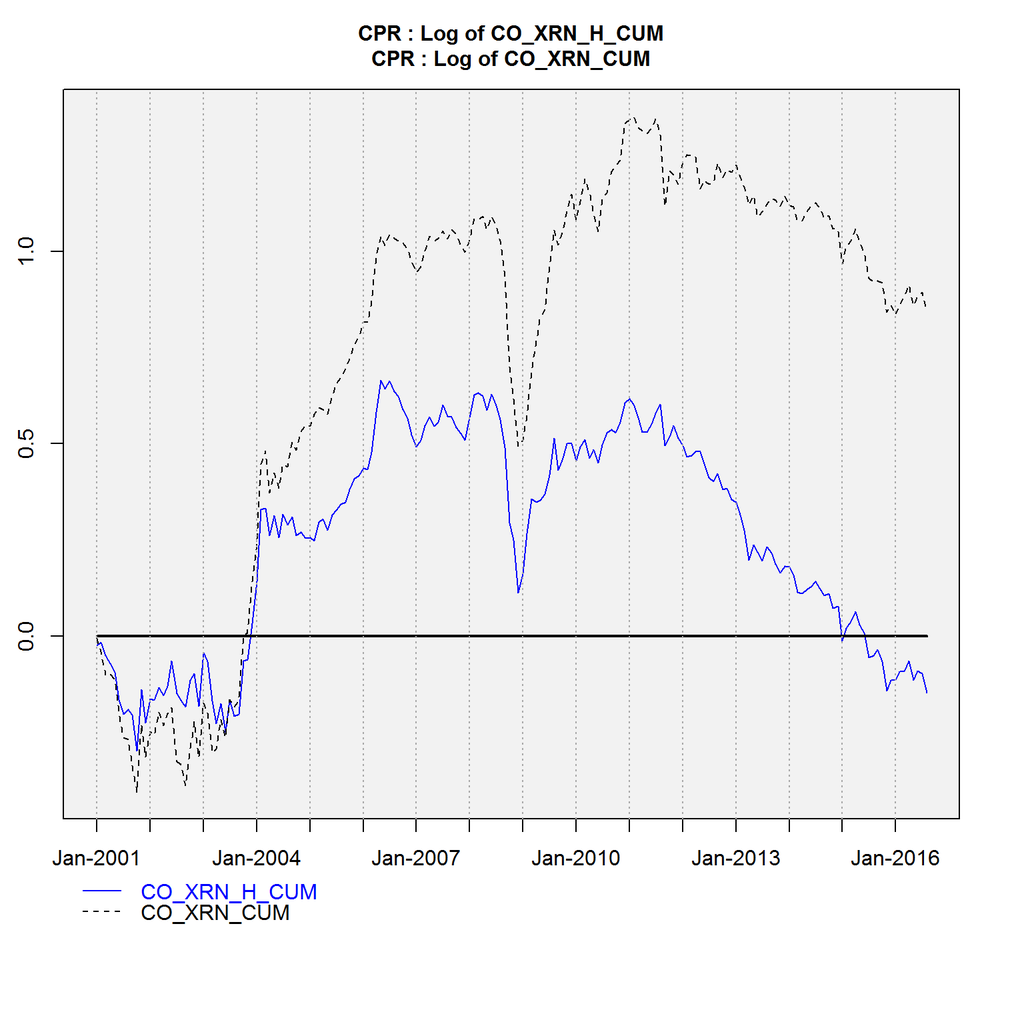

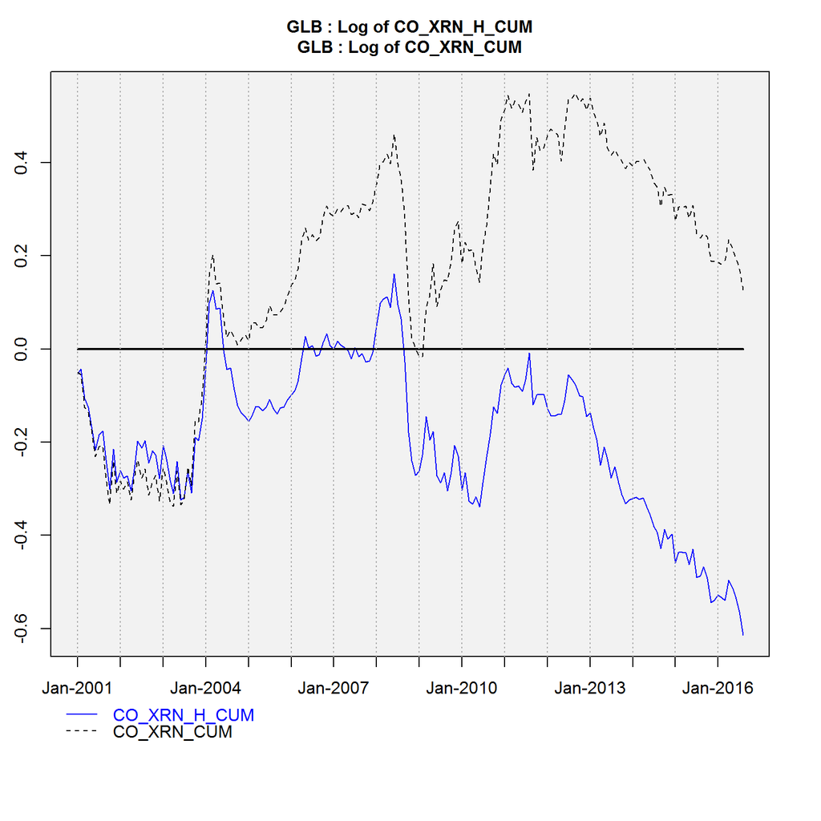

There has been on average positive correlation across all groups of commodities, i.e. crude oil (OIL), industrial metals (IDM), precious metals (PRM), U.S. corn belt crops (CBC), coffee & sugar (CFS), and livestock (LVS). However, not all correlations have been high, as the below pearson correlation coefficient matrix shows. Livestock has been almost uncorrelated with the other categories. Many other group cross correlations have been in a 20-30% range.

|  | OIL_CO_XRN | IDM_CO_XRN | PRM_CO_XRN | CBC_CO_XRN | CFS_CO_XRN |
| --- | --- | --- | --- | --- | --- |
| IDM_CO_XRN | 0.42 |  |  |  |  |
| PRM_CO_XRN | 0.298 | 0.27 |  |  |  |
| CBC_CO_XRN | 0.286 | 0.347 | 0.239 |  |  |
| CFS_CO_XRN | 0.242 | 0.379 | 0.31 | 0.334 |  |
| LVS_CO_XRN | 0.134 | 0.12 | -0.069 | 0.112 | -0.012 |

Across sections, intra-group correlation coefficients become very high, up to a 62-73% correlation range for the top five. Yet average correlation has been just 26%. This is below the 31% average cross-correlation for EM FX forwards.

One can estimate GDRB betas for normalized returns, based on daily, weekly, and monthly frequencies in equal weights and with intuitive and exponentially decaying look-back windows. Directional hedging based on these betas has been effective in lowering the out-of-sample correlation of returns with the basket. The ratio of hedged versus unhedged rolling correlations was 57% and ratio of hedged to unhedged standard deviations was 95%. Any of the individual frequencies results in higher ratios.

Betas have on average been positive for all commodities (with copper being the highest and lean hogs being the lowest) and only occasionally strayed into negative territory. There have been violent swings of estimated betas in the past for many commodities. Brent shifted from being uncorrelated to positive risk correlation after the great financial crisis. On the whole signs and measure of market dependence of most commodities seems to have increase overtime (due presumably to financialization), but remains circumstantial.

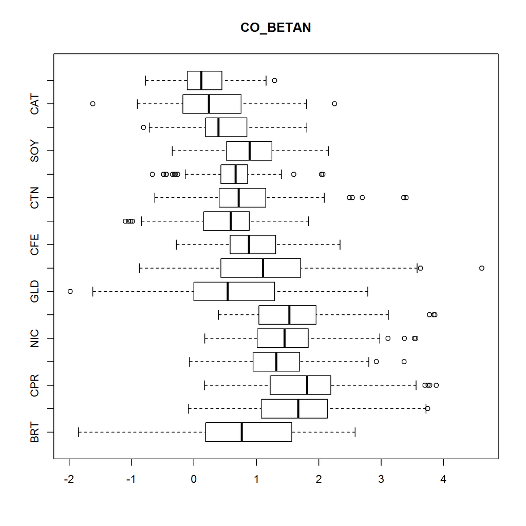

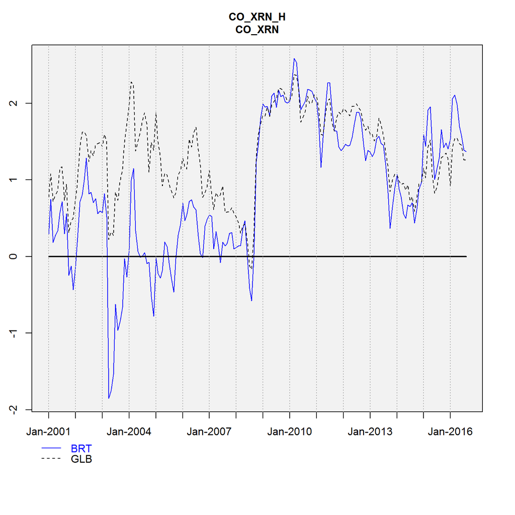

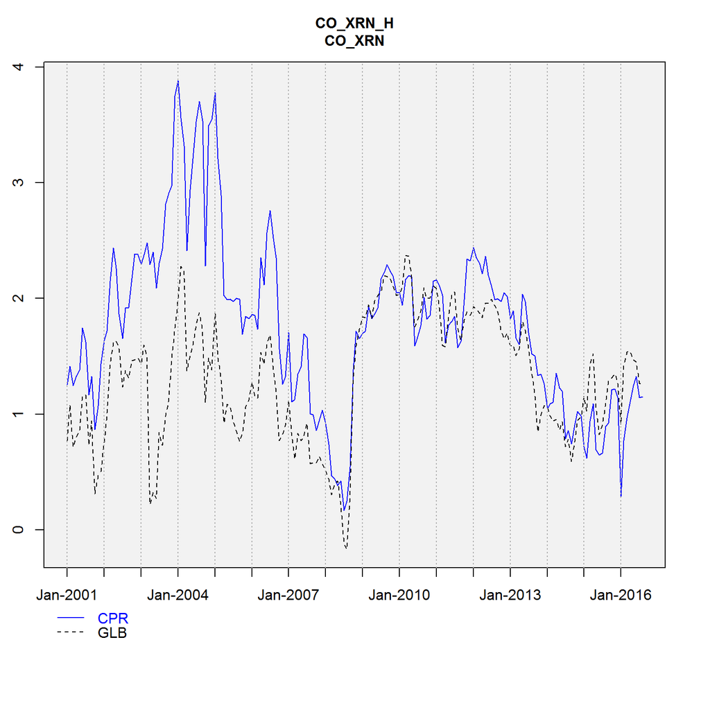

*LAST UPDATE Sep 2016*

## 1.3 Factors overview

## 1.4 Indicators

### 1.4.1 Subsidy: Calibrated carry measures

*Theoretical link*

Carry in this context is simply the log ratio of the first and second future price. It is considered to be a proxy for the curve shape. A positive carry means that the curve is in backwardation, and holding future turns a profit if the spot price and the overall curve remain unchanged. A negative carry implies that the curve is in contango, and holding the front future incurs a loss if all prices remain steady. The indicative nature of such a carry depends on the type of commodity, particular its ease of storage, but seems to be valid for most cases.

- If a **commodity has (almost) no storage cost**, its curve is formed similar to that of a zero bond. In a pure financial equilibrium a futures price would simply be equal to the spot price plus the cost of funding and the (negligible) cost of storage. In functioning markets the relation would always hold and carry would have no indicative value. Consequently, without serious frictions in markets there can be no carry-based value generation. This should be the case for gold and silver.
- If a **commodity has modest storage costs**, the curve will still be affected by financial arbitrage, but will also be influenced by the willingness of commodity producers or consumers to pay a premium or accept a discount on either the spot or the futures price. For example, the consumers of copper may be willing to pay a premium on the spot price to have easy access to the physical material, thereby causing positive carry for futures holders (convenience yield). Similarly, producers may be willing to sell future output at a discount, causing a similar effect. To the extent that consumers and producers pay for convenience or insurance services, a profit opportunity arises for financial investors. This should hold true for base metals and crude.
- If a **commodity has high storage costs** but can still be warehoused, the curve is more segmented and more strongly influenced by storage costs and should on average show a tendency towards contango in the front end. The segmentation is because physical traders would often find it expensive to store and wait, weakening the link between points in time on the curve. The contango is because physical traders and “storers” require the futures price to be significantly above the spot price to compensate for storage costs. Importantly, the futures price sur-charge that arises from the storage cost savings is still a valid discount on the future from the angle of the financial investor. Put differently, the financial investor would still predicate a profitable short on it, because unlike physical traders it does not forgo any storage cost savings. The same applies to all other motives of suppliers and consumers to pay a premium or accept a discount that differentiates the futures price from the expected spot price. This should apply to many agricultural commodities.
- If a **commodity is impossible** to store markets are segmented. In this case, physical traders will predominantly transact for the time the commodity is delivered or consumed, with little consideration of storage economics. The prices along the curve will be driven by final demand and supply and expectations thereof. To be sure, producers and consumers may pay a premium similarly as in the case of storable commodities. However, it is hard to quantify the premium and isolate it from genuine demand-supply dynamics. One way of mitigating the noise is seasonal adjustment and moving average formation (since premiums are often more structural).

The bottom line is that carry is a valid indicator for most commodities but may require some theory led adjustments to account for the varying influences of storage economics.

*Example for premium paid: Commodity prices and convenience yield*

In the theory of commodity storage, the convenience yield is a benefit that accrues to the holder of an inventory. Commodity inventories have an option value as they allow a consumer (such as a manufacturer) to meet unexpected demand for his produced good. They also allow overcoming situations of aggregate stock-out or disruptions in the supply chain. Gorton et al. (2012) empirically document the convenience yield of 31 com-modities and find that it is a decreasing, non-linear function of inventories. A high level of convenience yield, due to a low level of aggregate inventories, precedes a decrease in the price of the commodity as inventories return to their normal level. In the model of rational commodity pricing of Pindyck (1993) commodity convenience yields are forward-looking variables that incorporate information about future supply and demand conditions. It is weaker for commodities that are easy to store such as industrial metals and stronger for energy or agricultural commodities with strong seasonal factors.

The convenience yield is typically calculated net of storage costs. Some authors simply infer it from the following relation: $F = (1+r)*S-CY => CY = (1+r)*S-F$ ; where F is the futures price, S the spot price of the commodity, r the opportunity rate of interest, and CY the convenience yield.

A complementary aspect of the relationship between commodity spot and futures prices is the theory of normal backwardation (see Keynes, 1930; Hicks, 1939), which emphasizes the risk premium earned by risk-averse investors for the uncertainty on future spot prices. According to this theory, current futures prices are set at a discount (D) to the expected future spot price E[S].

$F = E[S]-D$

From this follows that expected commodity price changes are explained by three factors: capital cost (the higher the less inventory is held and the more future price increases), convenience yield (the higher, the more inventory is held), and supplier risk aversion (the higher, the lower the accepted and market futures price, which through the storage cost-benefit relation also reduces the spot price).

$E[S] = r*S-CY+D$

A useful empirical characteristic of commodity convenience yields for forecasting commodity currencies is that they are persistent but stationary variables, whereas commodity prices are generally non-stationary.

[http://www.nber.org/papers/w13249.pdf]

*Indicators*

**Normalized carry (CO_CRYNT)**: This is the log-ratio of the first and second futures price, annualized, expressed in percentage points and truncated at the 10% threshold. Grains and softs commodities carries have been seasonally adjusted, whereas easier to store hard commodities (base metals, precious metals, Brent) have not. Alternatives are 3-month averages (CO_CRYN_3MAT), to filter out convenience yield from other factors, and hedged carries to bring the implied subsidy more closely in line with returns (CO_CRYN_HT, CO_CRYN_H_3MAT). Truncating carries has had a massive impact, particularly in markets with low storability (chart below), and yet, heterogeneity across carries remains massive. There has been significant cross-sectional correlation with subsequent non-relative returns, but not much intertemporal correlation.

|  | CO_CRYNT |  |  |  | Comment |
| --- | --- | --- | --- | --- | --- |
| Heterogeneity | Max-min dist. in SD | 1.647 | Max-min SD ratio | 6.398 |  |
| Distribution | Excess kurtosis | 0.253 | Skewness | 0.303 |  |
| Correlation | AR(1) | 0.696 | Average cross | 0.076 |  |

|  | CO_CRYNT | vs. | CO_XRN_H |  | Comment |
| --- | --- | --- | --- | --- | --- |
| Correlation prob. | 1M/1M horizon | 99.6% | 3M/1M horizon | 100% |  |
| Reliability | Intertemporal | 62% | Cross-sectional | 81%-94% |  |

|  | CO_CRYN_HT |  |  |  | Comment |
| --- | --- | --- | --- | --- | --- |
| Heterogeneity | Max-min dist. in SD | 1.379 | Max-min SD ratio | 3.255 |  |
| Distribution | Excess kurtosis | 0.122 | Skewness | 0.74 |  |
| Correlation | AR(1) | 0.707 | Average cross | 0.08 |  |

|  | CO_CRYN_HT | vs. | CO_XRN_H |  | Comment |
| --- | --- | --- | --- | --- | --- |
| Correlation prob. | 1M/1M horizon | 99.2% | 3M/1M horizon | 100% |  |
| Reliability | Intertemporal | 44%-62% | Cross-sectional | 81%-88% |  |

|  | CO_CRYN_3MAT |  |  |  | Comment |
| --- | --- | --- | --- | --- | --- |
| Heterogeneity | Max-min dist. in SD | 1.831 | Max-min SD ratio | 6.027 |  |
| Distribution | Excess kurtosis | 0.374 | Skewness | 0.268 |  |
| Correlation | AR(1) | 0.904 | Average cross | 0.085 |  |

|  | CO_CRYN_3MAT | vs. | CO_XRN_H |  | Comment |
| --- | --- | --- | --- | --- | --- |
| Correlation prob. | 1M/1M horizon | 100% | 3M/1M horizon | 100% |  |
| Reliability | Intertemporal | 69%-75% | Cross-sectional | 75%-88% |  |

|  | CO_CRYN_H_3MAT |  |  |  | Comment |
| --- | --- | --- | --- | --- | --- |
| Heterogeneity | Max-min dist. in SD | 1.54 | Max-min SD ratio | 3.342 |  |
| Distribution | Excess kurtosis | 0.056 | Skewness | 0.692 |  |
| Correlation | AR(1) | 0.908 | Average cross | 0.084 |  |

|  | CO_CRYN_H_3MAT | vs. | CO_XRN_H |  | Comment |
| --- | --- | --- | --- | --- | --- |
| Correlation prob. | 1M/1M horizon | 100% | 3M/1M horizon | 100% |  |
| Reliability | Intertemporal | 69%-75% | Cross-sectional | 81%-94% |  |

*Charts*

Normiliazed carries display extreme heterogeneity, which is alleviated by the truncation at 10%. This affects mostly agricultural commodities, which are generally in contango (negative carry) but on occasion (market stress) display large positive carries (positive carries).

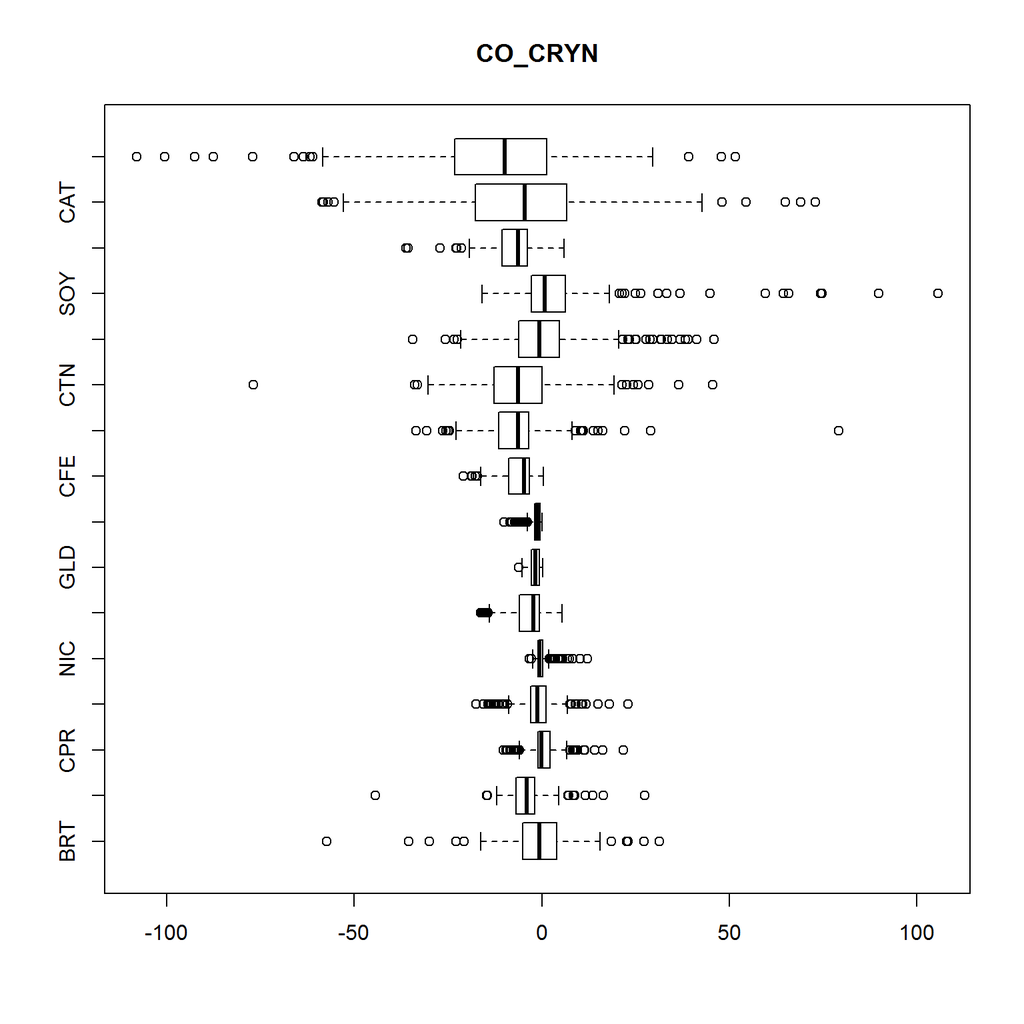

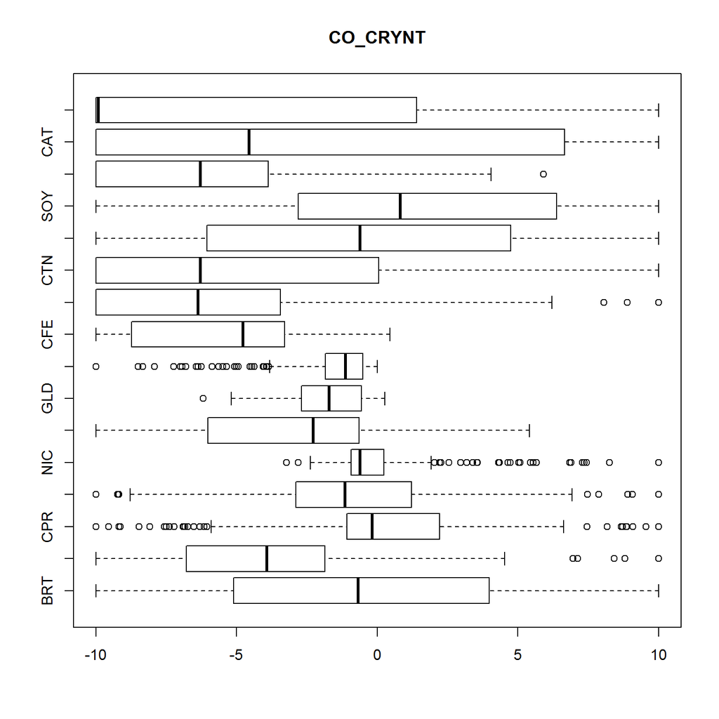

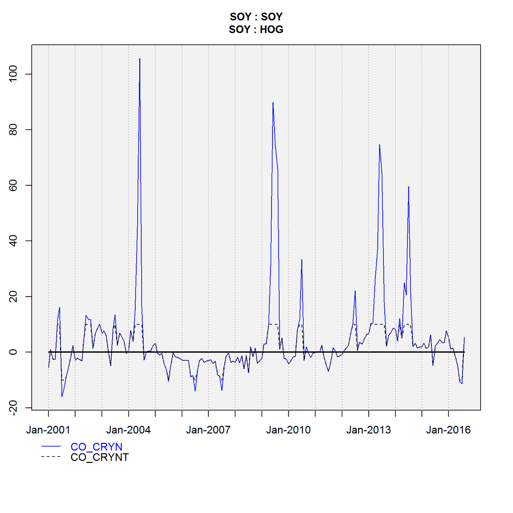

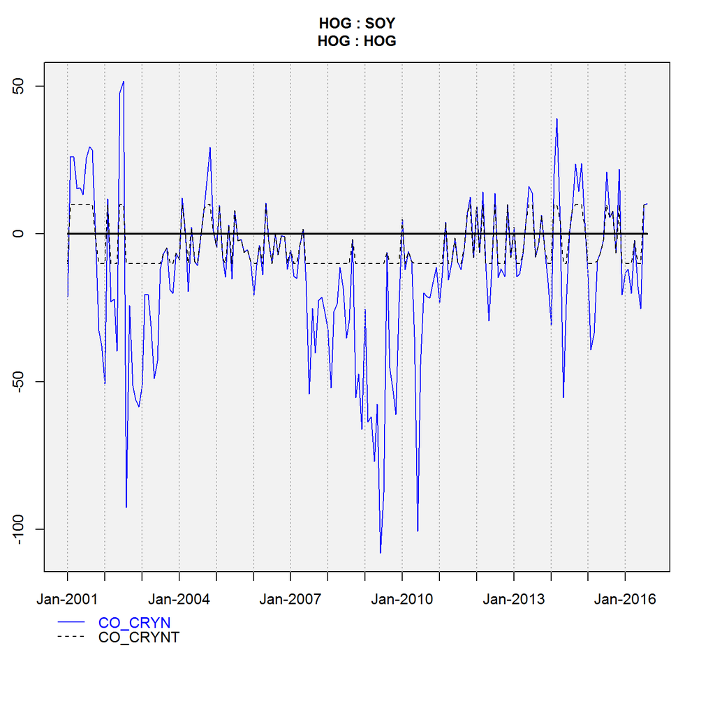

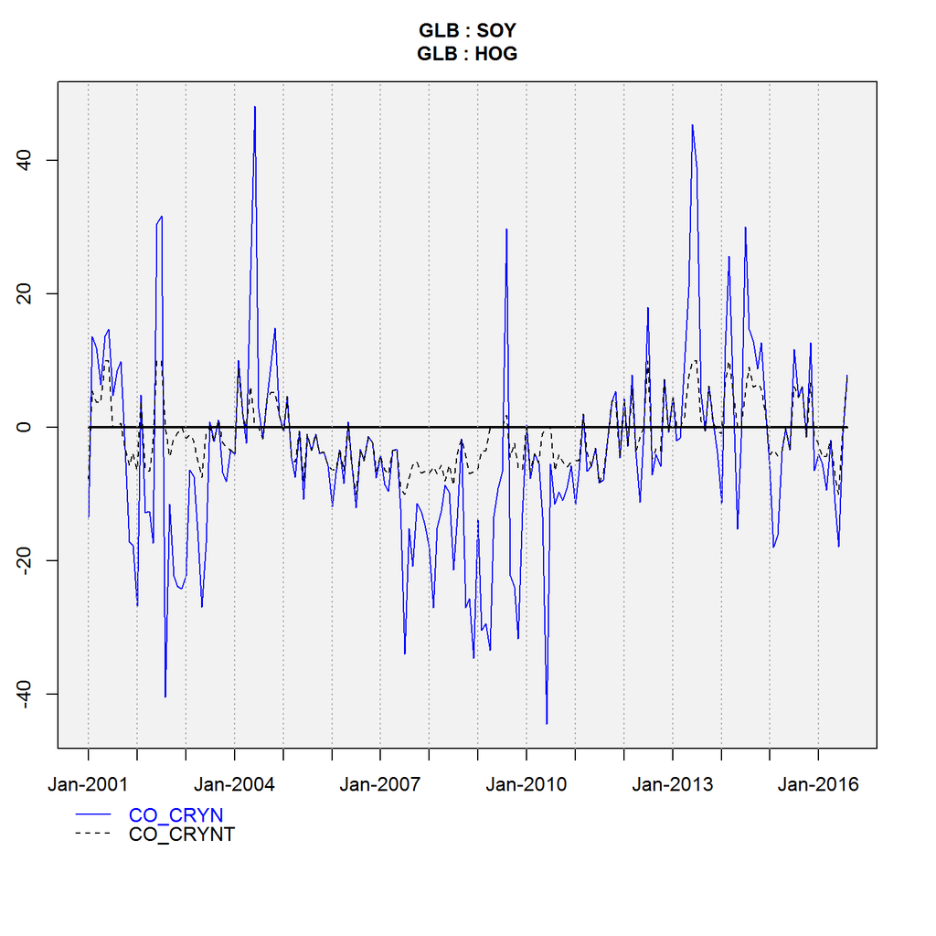

*Predictive power*

|  | CO_CRYNTRZ | vs. | CO_XRN_HR |  | Comment |
| --- | --- | --- | --- | --- | --- |
| Correlation prob. | 1M/1M horizon | 100% | 3M/1M horizon | 100% |  |
| Reliability | Intertemporal | 69%-81% | Cross-sectional | 81%-94% |  |
| NaÃ¯ve Sharpe | Digital | 0.834 | Proportional | 0.668 |  |
| Quality | GDRB correlation | -10.5% | Long bias | 0.48 |  |

|  | CO_CRYN_HTRZ | vs. | CO_XRN_HR |  | Comment |
| --- | --- | --- | --- | --- | --- |
| Correlation prob. | 1M/1M horizon | 100% | 3M/1M horizon | 100% |  |
| Reliability | Intertemporal | 69%-75% | Cross-sectional | 81%-88% |  |
| NaÃ¯ve Sharpe | Digital | 0.828 | Proportional | 0.653 |  |
| Quality | GDRB correlation | -5% | Long bias | 0.4 |  |

|  | CO_CRYN_3MATRZ | vs. | CO_XRN_HR |  | Comment |
| --- | --- | --- | --- | --- | --- |
| Correlation prob. | 1M/1M horizon | 100% | 3M/1M horizon | 100% |  |
| Reliability | Intertemporal | 81%-88% | Cross-sectional | 75%-88% |  |
| NaÃ¯ve Sharpe | Digital | 0.85 | Proportional | 0.828 |  |
| Quality | GDRB correlation | -6.5% | Long bias | 0.49 |  |

|  | CO_CRYN_H_3MATRZ | vs. | CO_XRN_HR |  | Comment |
| --- | --- | --- | --- | --- | --- |
| Correlation prob. | 1M/1M horizon | 100% | 3M/1M horizon | 100% |  |
| Reliability | Intertemporal | 75%-81% | Cross-sectional | 81%-94% |  |
| NaÃ¯ve Sharpe | Digital | 0.973 | Proportional | 0.774 |  |
| Quality | GDRB correlation | -1.7% | Long bias | 0.41 |  |

One can construct 3-month averages of trimmed carries, based on the argument that convenience yields plausibly come in long trends or are even structural. Long-term Sharpe ratios have indeed been slightly higher.

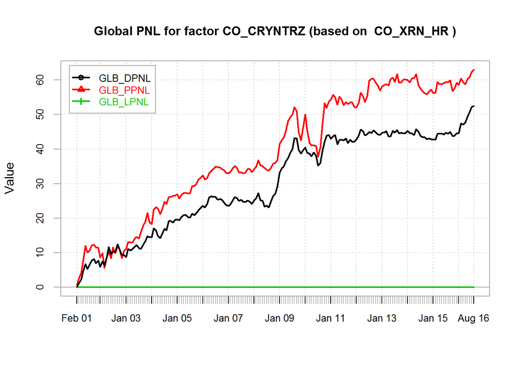

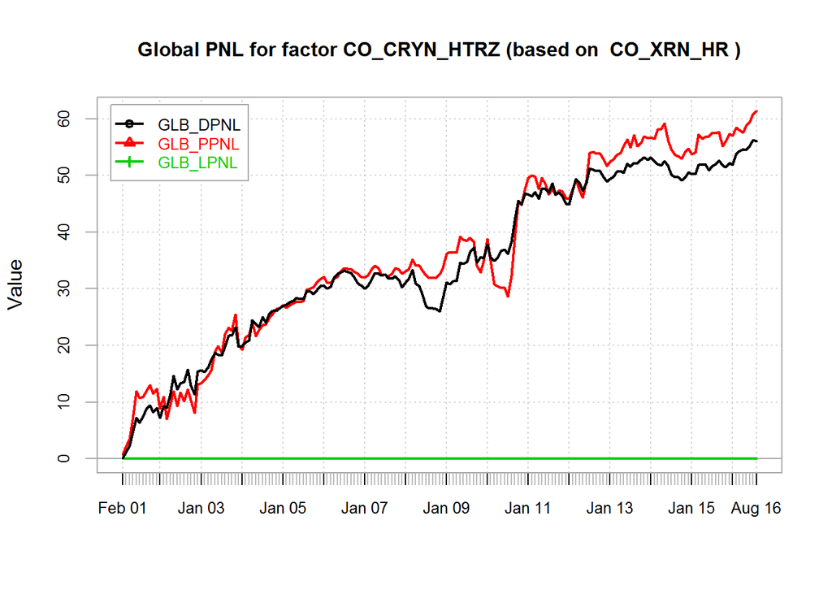

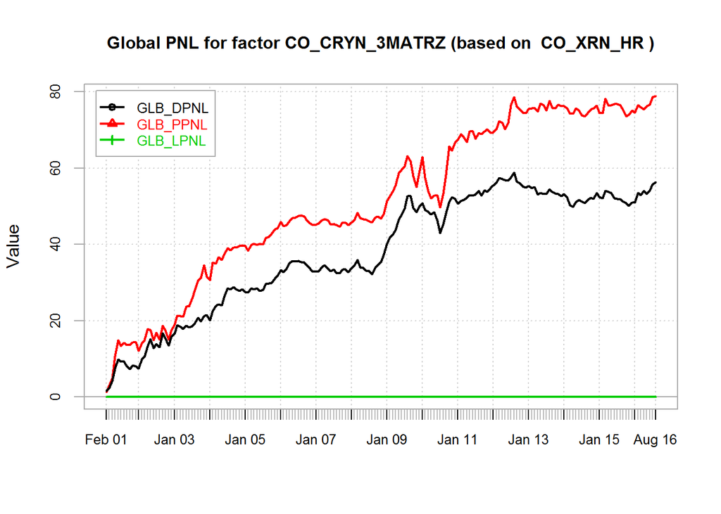

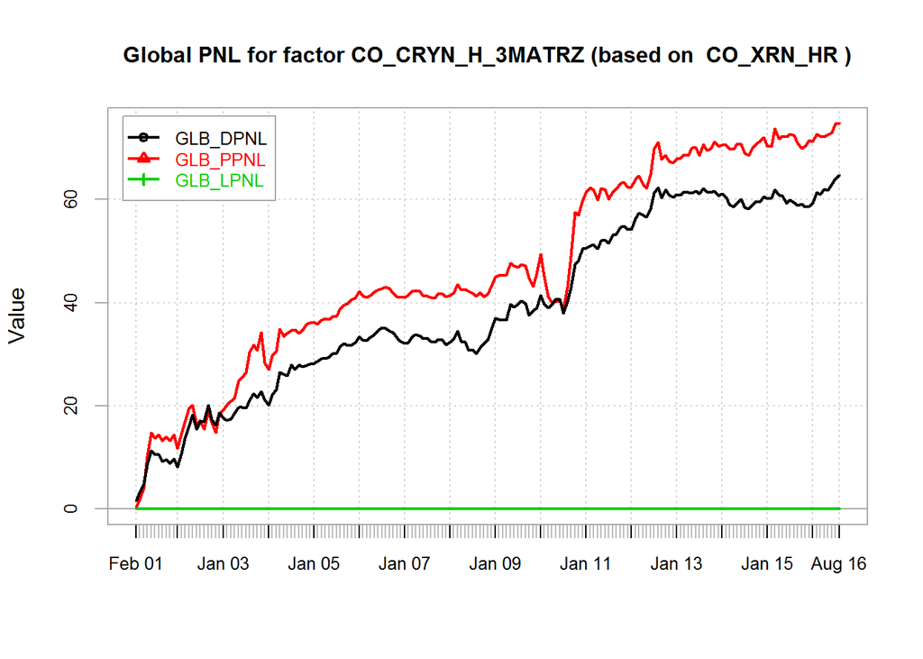

*LAST UPDATE Sep 2016*